# Time Series Analysis for Steelhead Trout

Benson Truong

#### **Introduction**

Steelhead trout are anadromous fish species that are economically important as commercial fisheries and culturally important to Native American Tribes. It is crucial to analyze steelhead trout populations to explain trends and fluctuations. In this study, a daily, seasonal, and annual time series plot is presented. The counts of steelhead trout passage data were collected at the Bonneville Dam from 1940 - 2019 and provided by the Columbia Basin Research.

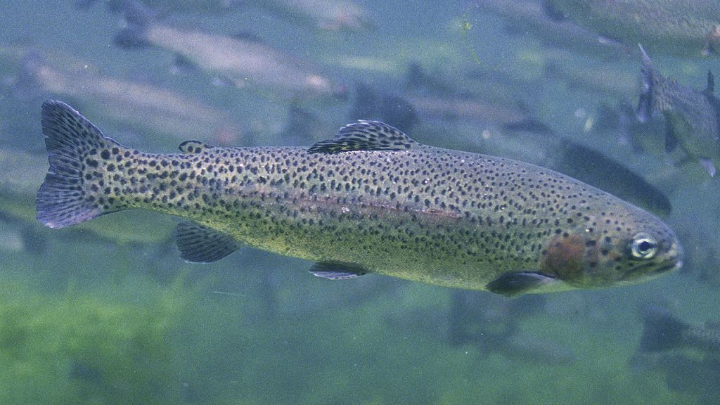

*Photo of a Steelhead Trout.* *Credit:* [*CBS*](https://sanfrancisco.cbslocal.com/2016/03/14/steelhead-trout-seen-in-alameda-creek-watershed-for-1st-time-in-years/)

#### **Figures**

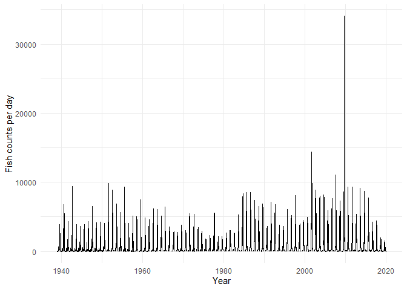

```r
# First graph
ggplot(data = fish_ts, aes(x = year_month_day, y = value)) +
  geom_line()+
  labs(x = "Year", y = "Fish counts per day")+
  theme_minimal()
```

*Figure 1.* *Daily Time Series Plot*

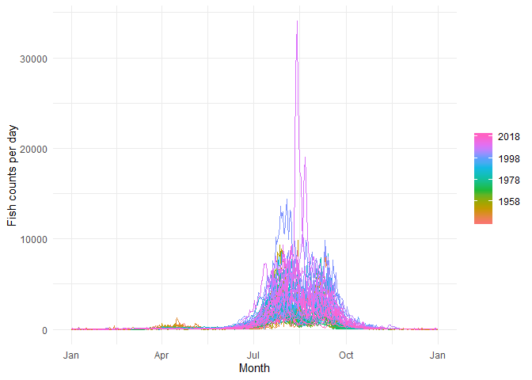

```r
# Second Graph
fish_ts %>% gg_season(value) +
  theme_minimal()+
  labs(x = "Month", y = "Fish counts per day")
```

*Figure 2.* *Seasonal Time Series Plot*

Seasonal time series plot illustrates that most Steelhead trout passage counts were observed from July to October. This means that Steelhead fish migrate up the Bonneville Dam in the summer to reproduce.

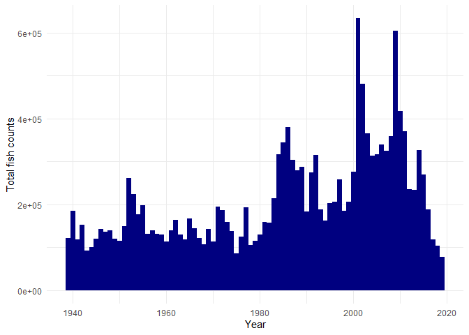

```r
# Third Graph
ggplot(data = annual_fish, aes(x = year, y = counts))+
  geom_col(fill = "navy", width = 1)+
  labs(x = "Year", y = "Total fish counts")+
  theme_minimal()
```

*Figure 3.* *Annual Steelhead Passage Counts from Years 1940 - 2019.*